# MetabolomicsPipeline: An R package for targeted metabolomics research.

Joel Parker https://publichealth.arizona.edu/ (University of Arizona) , Lisa White https://bio5.org/ (University of Arizona) , Bonnie Lafleur https://www.pharmacy.arizona.edu/person/bonnie-lafleur-0 (University of Arizona)  
2022-11-09

## 1 Introduction

Targeted metabolomics assays quantify a set of predefined small molecules known as metabolites (Roberts et al. 2012). These assays categorize metabolites into sub-pathways based on biological function and further organize sub-pathways into super-pathways. Companies like Metabolon Inc. utilize proprietary pipelines for preprocessing, exploratory data analysis, and statistical analysis. These pipelines provide customers with raw data, processed data, and analysis results.

While proprietary data analysis workflows can provide researchers with valuable results, they often do not adhere to the F.A.I.R guiding principles for reproducible research, which extends to workflows and pipelines (Goble et al. 2020). Specifically, proprietary pipelines are not reusable and do not allow researchers to replicate the results. Moreover, proprietary workflows are limited to the types of analysis they can perform, with little flexibility to make data-driven analysis decisions. In contrast, utilizing open source software like R to build analysis workflows and distribute them through centralized repositories like the Comprehensive R Archive Network (CRAN) or Bioconductor enables the reuse of workflows for secondary analysis and promotes reproducible research.

For R, several packages are available to analyze targeted metabolomics data. Packages like autonomics (Bhagwat et al. 2024) and MetaboloAnalysistR (Pang et al. 2020) provide open-source tools for preprocessing, batch correction, and analysis of targeted metabolomic data. However, these tools only offer functionality for hypothesis testing at the metabolite level and do not support hypothesis testing at the sub-pathway level. When hypothesis testing at the sub-pathway level is of interest, we can independently test each metabolite and then combine the p-values within each sub-pathway using the combined Fisher probability test (Westberg 1985). Despite this being an efficient method for hypothesis testing at the sub-pathway level, to the best of our knowledge, there is no R package that implements this method for sub-pathway testing.

In this article, we introduce and demonstrate the MetabolomicsPipeline R package. This package provides analysis tools for targeted metabolomics data, categorized into three categories (figure 1):

- Exploratory analysis
- Sub pathway analysis
- Metabolite pairwise comparisons

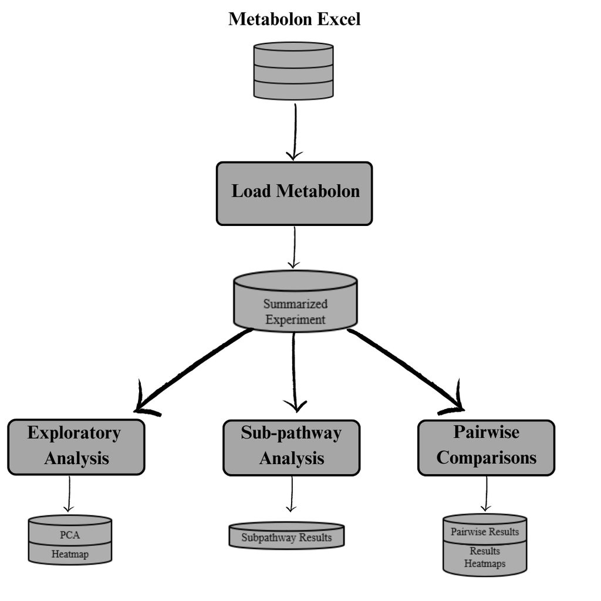

Figure 1: MetabolomicsPipeline workflow

The MetabolomicsPipeline package utilizes the SummarizedExperiment (M et al. 2024) package to organize targeted metabolomics data into a standard data structure, facilitating easy integration into preexisting genomic workflows. Analysts can create interactive heatmaps to sort through and interpret analysis results quickly. In addition to the R package, an R shiny app is available with all of the functionality of the R package, providing an intuitive and interactive interface for users.

The remainder of this paper is organized as follows. Section 2 discusses the package design and structure, providing detailed information on the analysis methods and algorithms used. Section 3 illustrates the application of the package through a case study using targeted metabolomic data from Metabolon.

## 2 Package Design

Metabolon Inc. provides customers with raw, batch-corrected, and standardized data generated from their proprietary pipeline. Additionally, they include chemical annotation data, detailing the sub-pathway and super-pathway for each metabolite, as well as sample metadata for each sample in the experiment. Metabolon consolidates all this information into a single Excel file. By organizing the experimental data into a SummarizedExperiment class, users can maintain all relevant information throughout the entire workflow. While the MetabolomicsPipline package includes wrappers for quickly loading Metabolon Inc. experiments into a SummarizedExperiment using the ‘load_metabolon’ function, the rest of the MetabolomicPipeline package is versatile enough to analyze experimental data from any targeted metabolomics assay that can be organized into a SummarizedExperiment data class. Figure 2, shows how to organize targeted metabolomics data into a SumarizedExperiment. Leveraging the functionality of the SummarizedExperiment data class facilitates easy integration of the MetabolomicsPipeline into multi-omics pipelines (Hutchison et al. 2024).

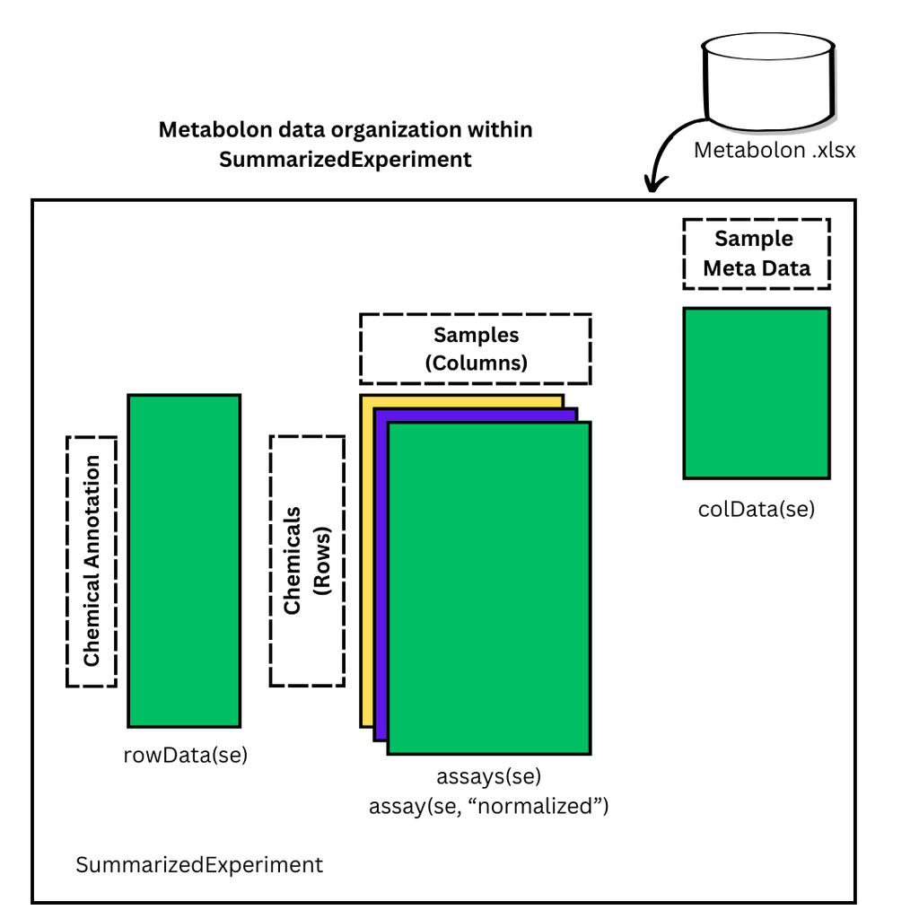

Figure 2: Organization of Metabolon Inc data into a SummarizedExperiment

Once the data is loaded into a SummarizedExperiment, the types of analyses can be categorized into three main categories described in Figure 1. In the following subsections, we detail the exploratory analysis, sub-pathway analysis, and metabolite analysis. We also demonstrate the functionality within the MetabolomicsPipeline package to help researchers visualize and interpret the results.

### 2.1 Exploratory analysis

The MetabolomicsPipeline package provides visualization tools that overlap with a few preexisting pipeline lines. In the exploratory analysis, we include PCA and heatmap visualizations, which allow us to graphically display sources of variation within the assay data.

Trying to visualize technical or biological sources of variation in the metabolomic profiles is challenging due to the high dimensional nature of the data. PCA is a valuable tool for reducing the dimensionality of the data by transforming the high dimensional data into new uncorrelated variables (principal components) that explain a maximal amount of the variance in the original data. Plotting the first two principal components together in a scatter plot reveals meaningful groupings and sources of variation. PCA also serves as a valuable quality control tool by highlighting technical sources of variation and may influence upstream and downstream analysis decisions. For example, if samples from different batches group together, the data must be batch-corrected before continuing with the downstream analysis. Using the `metabolite_pca` function, users can simultaneously calculate and plot the principal components while highlighting factors contributing to the variation in the metabolomic data.

Heatmaps are versatile tools for visualizing metabolite trends and spotting correlations within the data. The `metabolite_heatmap` function in the MetabolomicsPipline package displays the top metabolites based on the average metabolite levels. This function organizes data within a SummarizedExperiment to leverage the functionality of the pheatmap (Kolde 2019) package to create well-annotated heatmaps. Annotated heatmaps allow researchers to easily spot trends and/or abnormalities across the experimental conditions.

### 2.2 Sub-pathway analysis

Targeted metabolomic assays quantify predefined metabolites. Therefore, the assay data contain the amount of each chemical compound in each sample, where each sample is a replicate of the experimental conditions of interest. The metabolites are classified into predefined groups, called sub-pathways, based on their biological functions. These sub-pathways are further grouped within broader categories known as super-pathways. After preprocessing and standardization, researchers commonly use univariate analysis of variance (ANOVA) to test if a significant amount of variance in the metabolite levels is explained by the experimental groups . While this is effective for independently testing each metabolite, it does not allow us to test the hypotheses at the sub-pathway level where each sub-pathway contains one or more metabolites.

To test metabolic profiles at the sub-pathway level, we can combine the results for each independently tested metabolite within the sub-pathway using the combined Fisher probability method (Westberg 1985). To explain the details of this method, we will first explain the modeling procedure at the metabolite level and then explain how the results are combined. The following modeling strategy outlines the `subpathway_analysis` function in the MetabolomicsPipline package.

For each metabolite, we consider experimental designs that can utilize two-way ANOVA, such as randomized block designs. We employ a nested ANOVA modeling strategy to consider three different models.

1.) Interaction: $metabolite = Treatment Group + block + Treatment*block$

2.) Parallel: $metabolite = Treatment Group + block$

3.) Single: $metbabolite= Treatment$

In the interaction model, we test for a significant interaction between the treatment and block variables, focusing on the p-value for the interaction term. In contrast, the parallel model examines the treatment and block variables without the interaction term, assessing whether the blocking variable explains a significant amount of variation in the metabolite levels; thus, we only consider the p-value pertaining to the block variable. Lastly, the final model includes only the treatment group to determine if there are significant differences in average metabolite levels tbetween treatment group.

Once we have the p-values for each model, we can test the hypothesis from each model at the sub-pathway level using the combined Fisher probability method. In this method, the p-values for each independently tested metabolite within the sub-pathway are transformed and summed to create the chi-squared test statistic $X$ using the following function:
$$X = -2\sum_{i=1}^k ln(p_i)$$
where $k$ is the number of metabolites within the sub-pathway. The resulting test statistic $X$ follows a chi-squared distribution with $2k$ degrees of freedom. This allows us to combine the p-values from multiple independent tests into a single test at the sub-pathway level.

The MetabolomicsPipeline package also provides ways to summarize the sub-pathway analysis results, including:

- Significant sub-pathways by model (subpath_by_model)
- Proportion of significant sub-pathways within super pathways (subpath_within_superpath)
- Metabolite results within sub-pathways (met_within_sub)

Additionally, the package provides functionality to help visualize the data within sub-pathways identified in the sub-pathway analysis. Using the `subpathway_lineplot` and `subpathway_boxplot` functions, users can efficiently create line plots and box plots for each metabolite within a sub-pathway. These functions leverage the ggplot2 package, allowing users to tailor the plots to their needs.

### 2.3 Pairwise comparisons

We can compare group means between the experimental groups to identify metabolites that differ between them. When the metabolite levels are on the log scale, this translates to differences in log fold changes between groups. The MetabolitePipeline package provides functionality to test all pairwise group comparisons for each metabolite using the `metabolite_pairwise` function. The challenge with comparing pairwise group means, is preserving the family-wise error rate (FWER). If each comparison is performed with a significance level of $\alpha=0.05$, then the FWER (the probability of incorrectly rejecting at least one test) increases.

A first step to preserving the FWER at a prespecified level is to first filter metabolites using ANOVA to test if any of the experimental group means were significantly different. Metabolites showing an overall difference in group means are then subjected to pairwise comparisons. The `metabolite_pairwise` function provides the p-value for the overall test of significance as well as the unadjusted p-values for each of the pairwise comparisons. This allows the analyst the freedom to use any post-hoc p-value adjustment for their specific need.

The MetabolomicsPipline package provides tools for summarizing the results from pairwise comparisons using heatmaps. Specifically, the ‘metabolite_est_heatmap’ and the ‘metabolite_pvalue_heatmap’ functions create heatmaps that organize metabolites in the rows and pairwise comparisons in the columns, providing a visual summary of mean difference estimates and p-values. Below, we highlight a few details about the heatmaps.

- Inclusion Criteria: Metabolites that do not reject the overall test of significance at the $\alpha = 0.05$ level are excluded from both heatmaps.
- Organizational Structure: Metabolites grouped by sub-pathway.
- Mean difference heatmap (metabolite_est_heatmap): This heatmap highlights group comparisons with a mean difference greater than 2. When the metabolite data is on the log scale, this corresponds to a log fold change greater than 2.
- P-value heatmap (metabolite_pvalue_heatmap): This heatmap highlights group comparisons with a statistically significant mean difference.

Each heatmap has a static or interactive option. The interactive heatmap option is valuable because it allows users to zoom in on particular areas of the heatmap and quickly identify sub-pathways with several significant metabolites for a given comparison. Hovering over the heatmap provides useful information about the given metabolite, including metabolite name, sub-pathway, super-pathway, and pairwise comparison results.

## 3 Case Study

We start by loading the experiment data and showing the number of samples in each of the experimental groups. To create the summary table, we use the `table1` function from the table1 (Rich 2023) package to help create the table. The `loadMetabolon` function allows users to directly load Metabolon Inc data directly into a SummarizedExperiment. However, this example data is included in the MetabolomicsPipline package.

```r
# Load Metabolon data from the Excel file
# dat <- loadMetabolon(path = "../data/Metabolon.xlsx")
data("demoDat", package = "MetabolomicsPipeline")

dat <- demoDat


################################################################################
### Create Table 1 #############################################################
################################################################################
# Create table 1
tbl1 <- table1(~ GROUP_NAME + TIME1 | Gender,
    data = colData(dat)
)

# Display table 1
tbl1
```

|  | Female (N=44) | Male (N=42) | Overall (N=86) |
| --- | --- | --- | --- |
| GROUP_NAME |  |  |  |
| Control | 14 (31.8%) | 14 (33.3%) | 28 (32.6%) |
| treat1 | 15 (34.1%) | 14 (33.3%) | 29 (33.7%) |
| treat2 | 15 (34.1%) | 14 (33.3%) | 29 (33.7%) |
| TIME1 |  |  |  |
| End | 14 (31.8%) | 15 (35.7%) | 29 (33.7%) |
| Onset | 15 (34.1%) | 14 (33.3%) | 29 (33.7%) |
| PreSymp | 15 (34.1%) | 13 (31.0%) | 28 (32.6%) |

### 3.1 Exploratory analysis example

To see if the gender is a source of variation in the metabolic profile, we use the “Gender” variable to highlight the male/female sample on the scatter plot of the first two principal components. To use the `metabolite_pca` function we include the following arguments:

- data: SummarizedExperiment with experiment data.
- Assay: Name of the assay to be used for the pairwise analysis (default=‘normalized’)
- meta_var: A metadata variable to color code the PCA plot by.

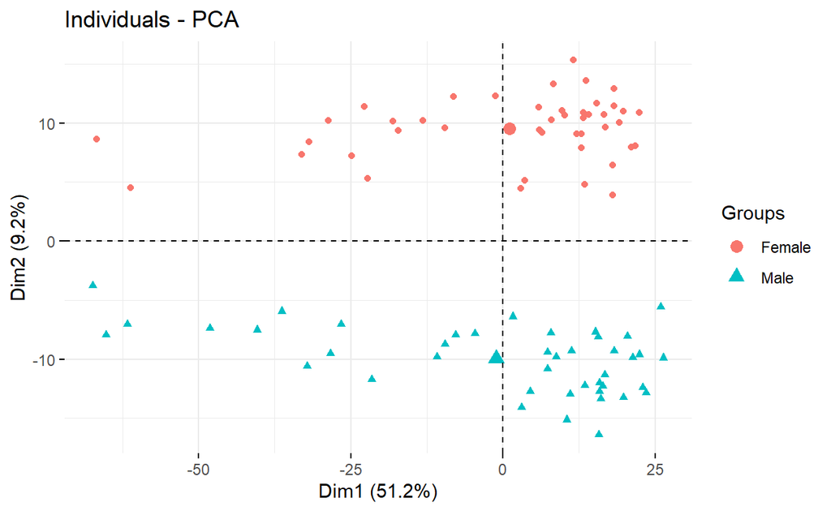

```r
# Colored by Gender
metabolite_pca(dat, Assay = "normalized", meta_var = "Gender")
```

The samples in the scatter plot above are clearly separated by male/female demonstrating that “Gender” is a source of variation we should account for in the downstream analysis.

The variables “GROUP_NAMES” and “TIME1” correspond to the treatment groups and time, respectively. We filter the the metabolites to only show the top 50 metabolites based on the average metabolite levels across all samples. We include the “GROUP_NAME” and “TIME1” variables to group the columns and annotate the heatmap. Based on the conclusions from the PCA above, we want to stratify the heatmaps by “Gender”. We are using the `metabolite_heatmap` function which requires the following inputs:

- data: A SummarizedExperiment containing the experiment data.
- top_mets: Number of metabolites to include in the heatmap. Metabolites are chosen based on the highest overall mean value.
- group_vars: variables to annotate heatmap with. Columns will be grouped by these variables.
- strat_var: Variable to stratify the heatmap by.
- caption: A title for the heatmap. If strat_var is used, the title will automatically include the stratum with the tile.
- Assay: Which assay data to use for the heatmap (default=“normalized”).
- sample_names: Column name in the meta data containing the sample names.
- … Additional arguments can be passed into the arrange function from dplyr to specify the order of the columns.

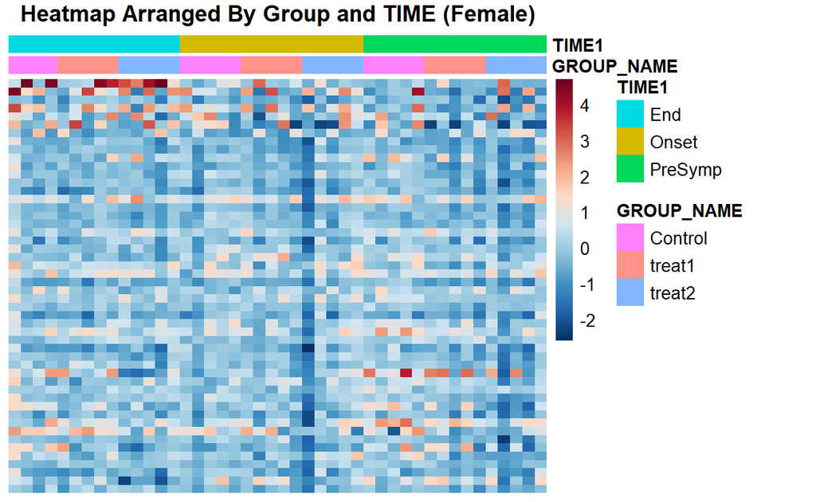

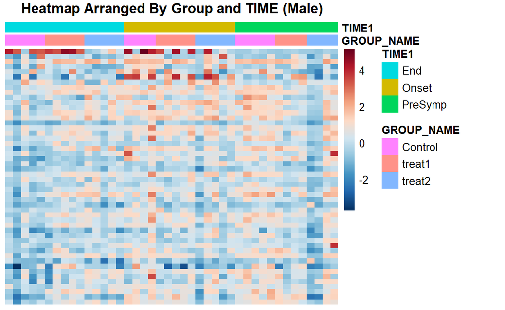

```r
# Heatmap with 2 group and stratified
metabolite_heatmap(dat,
    top_mets = 50,
    group_vars = c("GROUP_NAME", "TIME1"),
    strat_var = "Gender",
    caption = "Heatmap Arranged By Group and TIME",
    Assay = "normalized",
    sample_names = "PARENT_SAMPLE_NAME",
    TIME1,GROUP_NAME # Variables to use for annotation column names
)
```

These heatmaps additionally highlight differences in the metabolomic profiles of males and females within this experiment.

### 3.2 Sub-pathway analysis example

Next, we will test the interaction, parallel and single models at the sub-pathway level. As we identified above, we want to stratify this analysis by “Gender”. The subpathway_analysis function allows us to specify a variable to stratify the analysis automatically. We also summarize the results of the sub-pathway analysis in the following tables:

- Significant sub-pathways by model (subpath_by_model)
- Proportion of significant sub pathways within super pathways (subpath_within_superpath)
- Metabolite results within sub pathways (met_within_sub)

The subpathway_analysis function requires the following inputs:

- data: SummarizedExperiment with the experiment data.
- treat_var: This is the name of the variable in the analysis data that is the main variable of interest. Here we use “GROUP_NAME”.
- block_var: This is the name of the blocking variable in the dataset. Here we use “TIME1”.
- strat_var: Variable to stratify the sub-pathway analysis by. Here we use “Gender”
- Assay: Name of the assay to be used for the pairwise analysis (default=‘normalized’)
- subPathwayName: Column name for sub-pathway information
- chemName: Column name for chemical name variable as defined in the chemical annotation data.
- superPathwayName: Column name for super-pathway variable as defined in the chemical annotation data.

```r
################################################################################
## Stratified Analysis #########################################################
################################################################################

# Stratified Analysis
stratified <- subpathway_analysis(dat,
    treat_var = "GROUP_NAME",
    block_var = "TIME1",
    strat_var = "Gender",
    Assay = "normalized",
    subPathwayName = "SUB_PATHWAY",
    chemName = "CHEMICAL_NAME",
    superPathwayName = "SUPER_PATHWAY"
)


################################################################################
### Results Plots ##############################################################
################################################################################

# 1. significant subpathways by model type
subpathByModel <- subpath_by_model(stratified)

subpathByModel

# 2. Percentage of signficant subpathways within superpathways
subpathWithinSuperpath <- subpath_within_superpath(stratified)

subpathWithinSuperpath

# 3. Metabolites within subpathway
tables <- met_within_sub(stratified,
    subpathway = "Drug - Topical Agents"
)

### Females
tables[[1]]

### Males
tables[[2]]
```

[output not shown]

Based on the results of the sub-pathway analysis, the drug and topical sub-pathway may be of interest. We can visualize the data for each metabolite within the sub-pathway using the subpathway_boxplots function or the subpathway_lineplots function. Both of these functions require the following arguments:

- data: SummarizedExperiment with the experiment data.
- subpathway: Character value of the sub-pathway of interest. Here we are using “Drug - Topical Agents”.
- block_var: The name of blocking variable from the analysis. In this case “TIME1”
- treat_var: The name of the treatment variable (“GROUP_NAME”)
- Assay: Name of the assay to be used for the pairwise analysis (default=‘normalized’)
- CHEMICAL_NAME: Column name in the chemical annotation data which contains the chemical name.
- SUB_PATHWAY: Column name in chemical annotation data which contains the SUB_PATHWAY information
- …: Additional arguments to filter the analysis data by.

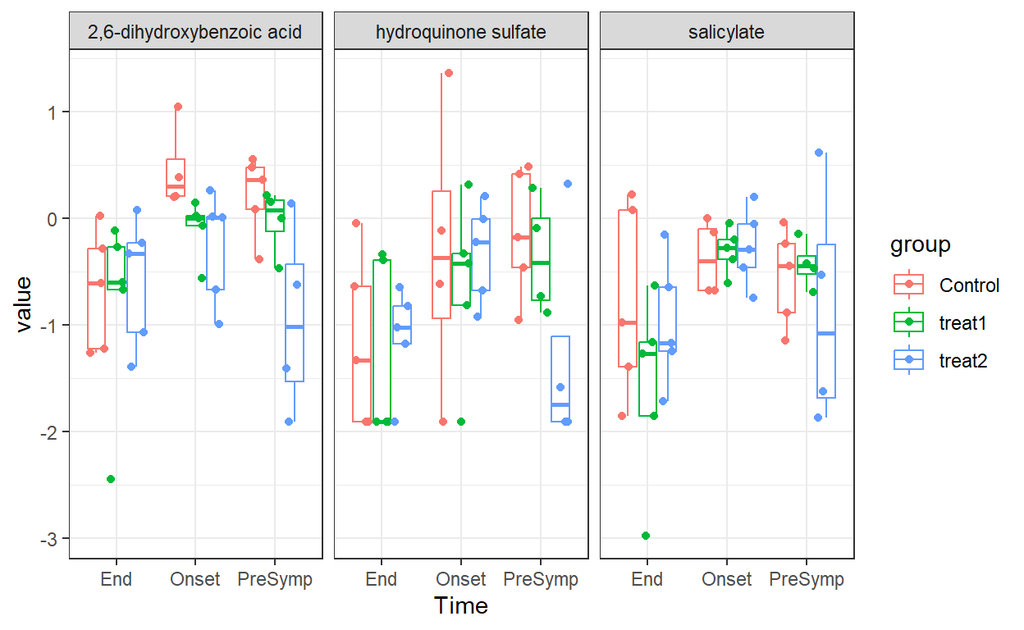

```r
################################################################################
### BoxPlots ###################################################################
################################################################################

subpathway_boxplots(dat,
    subpathway = "Drug - Topical Agents",
    block_var = TIME1,
    treat_var = GROUP_NAME,
    Assay = "normalized",
    CHEMICAL_NAME = "CHEMICAL_NAME",
    SUB_PATHWAY = "SUB_PATHWAY",
    Gender == "Male" # only using female samples
) +
  xlab("Time")
```

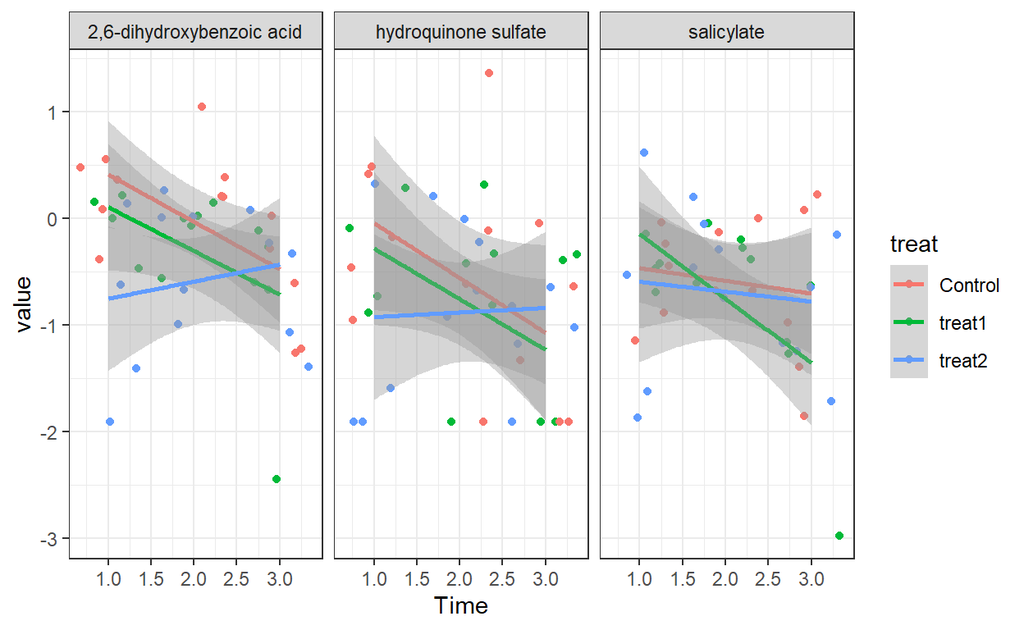

```r
################################################################################
## Line plots ##################################################################
################################################################################

# Set up data
dat$TIME2 <- as.numeric(factor(dat$TIME1,
    levels = c("PreSymp", "Onset", "End")
))

# Create line plots
subpathway_lineplots(dat,
    subpathway = "Drug - Topical Agents",
    block_var = TIME2, treat_var = GROUP_NAME,
    Assay = "normalized",
    CHEMICAL_NAME = "CHEMICAL_NAME",
    SUB_PATHWAY = "SUB_PATHWAY",
    Gender == "Male"
) +
    xlab("Time")
```

### 3.3 Pairwise comparisons example

Next we will look at all pairwise comparisons resulting in 36 total group comparisons. The inputs for the metabolite pairwise function are:

- data: SummarizedExperiment with the experiment data.
- form: This is a character string the resembles the right hand side of a simple linear regression model in R.
- Assay: Name of the assay to be used for the pairwise analysis (default=‘normalized’)
- strat_var: A variable in the analysis data to stratify the model by. Here were stratify by “Gender”
- mets: Chemical ID for the metabolites of interest. We leave this NULL to run the analysis on all metabolites.

We visualize the results using the met_est_heatmap and met_p_heatmap functions. Each of these functions includes an option (interactive = TRUE/FALSE) to specify whether the generated heatmap should be interactive. Here we only show the results for the female samples.

```r
################################################################################
#### Run Pairwise Comparisons ##################################################
################################################################################

strat_pairwise <- metabolite_pairwise(dat,
    form = "GROUP_NAME*TIME1",
    Assay = "normalized",
    strat_var = "Gender",
    mets = NULL
)
```

```r
###############################################################################
## Create Estimate Heatmap #####################################################
################################################################################

met_est_heatmap(strat_pairwise$Female, dat,
    interactive = TRUE,
     SUB_PATHWAY = "SUB_PATHWAY",
    CHEMICAL_NAME = "CHEMICAL_NAME",
    plotlyTitle = "Estimate Heatmap (Female)",
    main = "Log fold change heatmap"
)
```

[interactive chart not shown]

```r
################################################################################
## Create P-value Heatmap ######################################################
################################################################################
# Female
met_p_heatmap(strat_pairwise$Female, dat,
    interactive = TRUE, show_rownames = FALSE,
    plotlyTitle = "Pvalue Heatmap (Male)",
    main = "Pvalue Heatmap"
)
```

[interactive chart not shown]

```r
###############################################################################
## Create Estimate Heatmap #####################################################
################################################################################

met_est_heatmap(strat_pairwise$Female, dat,
    interactive = FALSE,
     SUB_PATHWAY = "SUB_PATHWAY",
    CHEMICAL_NAME = "CHEMICAL_NAME",
    plotlyTitle = "Estimate Heatmap",
    main = "Log fold change heatmap",
    show_rownames = FALSE
)



################################################################################
## Create P-value Heatmap ######################################################
################################################################################
# Female
met_p_heatmap(strat_pairwise$Female, dat,
    interactive = FALSE,
    plotlyTitle = "Pvalue Heatmap",
    main = "Pvalue Heatmap",
    show_rownames = FALSE
)
```

[output not shown]

## 4 Summary

Targeted metabolomics is a valuable tool for identifying biomarkers. Companies like Metabolon Inc. utilize proprietary software to analyze the data and deliver results to the customer. However, these types of software often do not follow reproducibility best practices, which can limit the transparency and repeatability of the research. In contrast, using open-source tools like R, facilitates reproducibility by allowing researchers to share and collaborate on open-source pipelines.

We demonstrated a new package, MetabolomicsPipeline, for analyzing targeted metabolomics data. The package contains tools for exploratory analysis, sub-pathway analysis, and pairwise comparisons across experimental groups. It supports data that can be organized into a SummarizedExperiment data class. This package also provides functionality to visually display the results from each analysis step, including various graphs and tables. When analyzing pairwise comparisons, users can create interactive heatmaps, enhancing the presentation of results. We provide all the functionality of the MetabolomicsPipeline through a user-friendly interface built with R Shiny, ensuring ease of use for researchers.

### 4.1 CRAN packages used

pheatmap

### 4.2 CRAN Task Views implied by cited packages

A. Bhagwat, R. Cotton, S. Hayat and J. Graumann. Autonomics: Unified statistical modeling of omics data. 2024. URL https://github.com/bhagwataditya/autonomics. R package version 1.12.1.

C. Goble, S. Cohen-Boulakia, S. Soiland-Reyes, D. Garijo, Y. Gil, M. R. Crusoe, K. Peters and D. Schober. FAIR computational workflows. *Data Intelligence*, 2(1-2): 108–121, 2020.

W. J. Hutchison, T. J. Keyes, T. Consortium, H. L. Crowell, J. Serizay, C. Soneson, E. S. Davis, N. Sato, L. Moses, B. Tarlinton, et al. The tidyomics ecosystem: Enhancing omic data analyses. *Nature Methods*, 1–5, 2024.

R. Kolde. *Pheatmap: Pretty heatmaps.* 2019. URL https://CRAN.R-project.org/package=pheatmap. R package version 1.0.12.

M. M, O. V, H. J and P. H. *SummarizedExperiment: SummarizedExperiment container.* 2024. URL https://bioconductor.org/packages/SummarizedExperiment. R package version 1.34.0.

Z. Pang, J. Chong, S. Li and J. Xia. MetaboAnalystR 3.0: Toward an optimized workflow for global metabolomics. *Metabolites*, 10(5): 186, 2020.

B. Rich. *table1: Tables of descriptive statistics in HTML.* 2023. URL https://CRAN.R-project.org/package=table1. R package version 1.4.3.

L. D. Roberts, A. L. Souza, R. E. Gerszten and C. B. Clish. Targeted metabolomics. *Current protocols in molecular biology*, Chapter 30: Unit30.2–30.2.24, 2012. DOI 10.1002/0471142727.mb3002s98.

M. Westberg. Combining independent statistical tests. *Journal of the Royal Statistical Society. Series D (The Statistician)*, 34(3): 287–296, 1985. URL http://www.jstor.org/stable/2987655 [online; last accessed July 13, 2024].